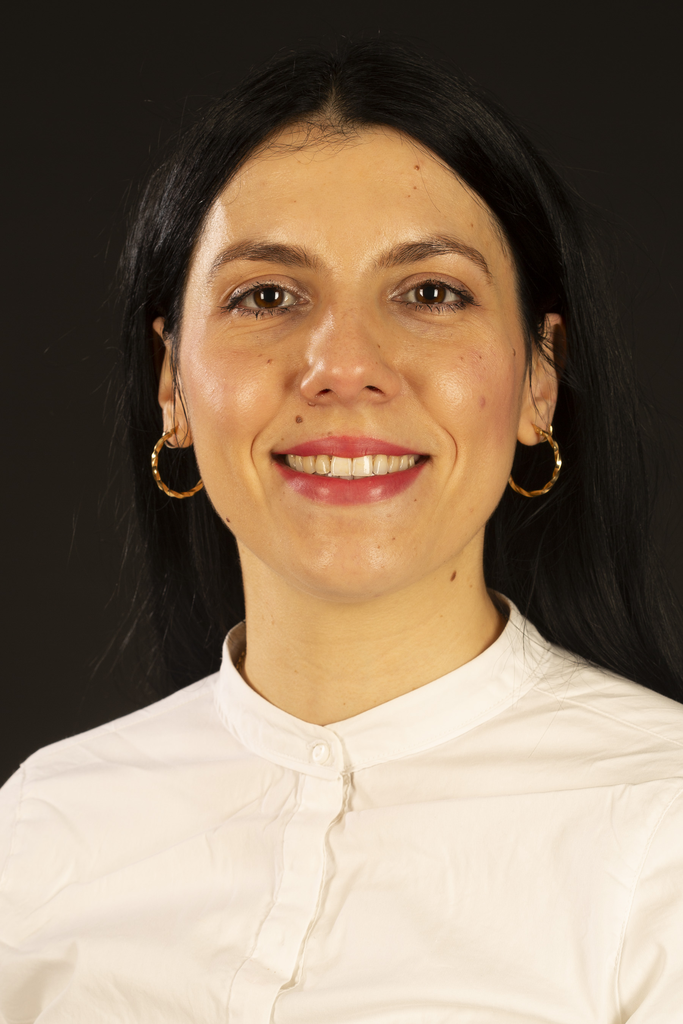

# Sonia Garcia-Ruiz

## Bio

I am a Computer Scientist living in Cambridge (UK). My research currently focuses on using short-read transcriptomic data to understand RNA splicing changes in human disease, with a special focus in neurodegeneration. But, of course, I also love talking about cats, music and philosophy.

## Education

**University College London** | London, UK

Ph.D. in Human Transcriptomics | August 2019 - Oct 2023

**University of Murcia** | Murcia, Spain

MS.c. in Artificial Intelligence | September 2017 - May 2018

**University Miguel Hernandez, Elche** | Alicante, Spain

B.S. in Computer Science | September 2010 - May 2014

## Experience

**UK Dementia Research Institute (UK DRI), Department of Clinical Neurosciences, University of Cambridge (UK)** | Postdoctoral Researcher | Sept 2024 - Present

**GOS Institute of Child Health, Department of Genetics and Genomic Medicine, University College London (UK)** | Postdoctoral Researcher | Oct 2023 - Sept 2024

**GOS Institute of Child Health, Department of Genetics and Genomic Medicine, University College London (UK)** | Research Assistant | Oct 2020 - Oct 2023

**Institute of Neurology, Department of Neurodegenerative Disease, University College London (UK)** | Research Assistant | Jul 2018 - Oct 2020

**Oesía Networks SL, Murcia (Spain)** | Software Developer | May 2015 - Dec 2017